# Data Science Capstone - SwiftKey Project

Cylia YACEF

2022-09-02

## 1- Introduction

This Milestone Report is about exploratory data analysis of the Capstone Project of the Data Science Coursera specialization.

Coursera and SwitfKey are partnering on this project; that apply data science in the area of natural language. The project uses a large text corpus of documents to predict the next word on preceding input.

The data is extracted and cleaned from files and used with the Shiny application.

Here, we have some information about the corpus of data and prepare a plan to create the predictive model.

The 3 files provided with language data from blogs, news and tweets are used to build the English language corpus.

The following steps are executed to prepare the data into a corpus.

```r
library(ggplot2)
library(tm)
library(stringi)
library(wordcloud)
library(RColorBrewer)
library(dplyr)
library(slam)
library(data.table)
library(NLP)
library(RWeka)
```

```r
# download file, if not present already
if( ! file.exists("Coursera-SwiftKey.zip") ){
  src_zip_file <- "https://d396qusza40orc.cloudfront.net/dsscapstone/dataset/Coursera-SwiftKey.zip"
  download.file(src_zip_file, destfile = "Coursera-SwiftKey.zip")
  unzip("Coursera-SwiftKey.zip")
}
```

```r
# look at the source files
zip_files <- unzip("Coursera-SwiftKey.zip", list = T)
zip_files$Date <- NULL
zip_files$Language <- substr(zip_files$Name, 7, 8)
zip_files$Length_in_Mb <- zip_files$Length/(1024^2)
zip_files <- zip_files[zip_files$Length>0,]
```

```r
# only load twitter
zip_files <- zip_files[ grep("en_US", zip_files$Name),  ]
```

## 2- Looking for the data

The data is from HC Corpora with access to 4 languages, but only English will be used. The dataset has three files: en_US.blogs.txt, en_US.news.txt, en_US.twitter.txt.

The data was loaded from Coursera Link to local machine and will be read from local disk.

```r
#Read en_US.blogs.txt, en_US.news.txt, en_US.twitter.txt.

blogsURL <- file("en_US.blogs.txt", open="rb")
blogs <- readLines(blogsURL, encoding = "UTF-8", skipNul=TRUE)

newsURL <- file("en_US.news.txt", open = "rb")
news <- readLines(newsURL, encoding = "UTF-8", skipNul=TRUE)

twitterURL <- file("en_US.twitter.txt", open = "rb")
twitter <- readLines(twitterURL, encoding = "UTF-8", skipNul=TRUE)
```

## 3- Some data statistics

```r
## Size of Files
S1 <- file.info("en_US.blogs.txt")$size / 1024^2
S2 <- file.info("en_US.news.txt")$size  / 1024^2
S3 <- file.info("en_US.twitter.txt")$size / 1024^2

## Number of lines
N1 <- length(blogs)
N2 <- length(news)
N3 <- length(twitter)

## Counting the Words
C1 <- sum(stri_count_words(blogs))
C2 <- sum(stri_count_words(news))
C3 <- sum(stri_count_words(twitter))

## The length of the longest line in any of the three en_US data sets
M1 <- max(nchar(blogs))
M2 <- max(nchar(news))
M3 <- max(nchar(twitter))
```

```r
resume <- data.frame(
        Name = c("Blogs","News","Twitter"),
        Size = c(S1, S2, S3),
        Nember_of_lines = c(N1, N2, N3),
        Nember_of_words = c(C1, C2, C3),
        max_size_Line = c(M1, M2, M3)
)
resume
```

```
##      Name     Size Nember_of_lines Nember_of_words max_size_Line
## 1   Blogs 200.4242          899288        37546250         40833
## 2    News 196.2775         1010242        34762395         11384
## 3 Twitter 159.3641         2360148        30093413           140
```

## 4- Data sampling

The data is enormous, so, we must create a subset of the data considering the limited resources for test and application.

```r
set.seed( 1984 )
dspl.blogs  <- sample(blogs,  5000,  replace = TRUE)
set.seed( 1984 )
dspl.news <- sample(news, 5000,  replace = TRUE)
set.seed( 1984 )
dspl.tweets <- sample(twitter ,   5000 ,  replace = TRUE)

# blending texts together
dspl <- c(dspl.blogs, dspl.tweets, dspl.news)
```

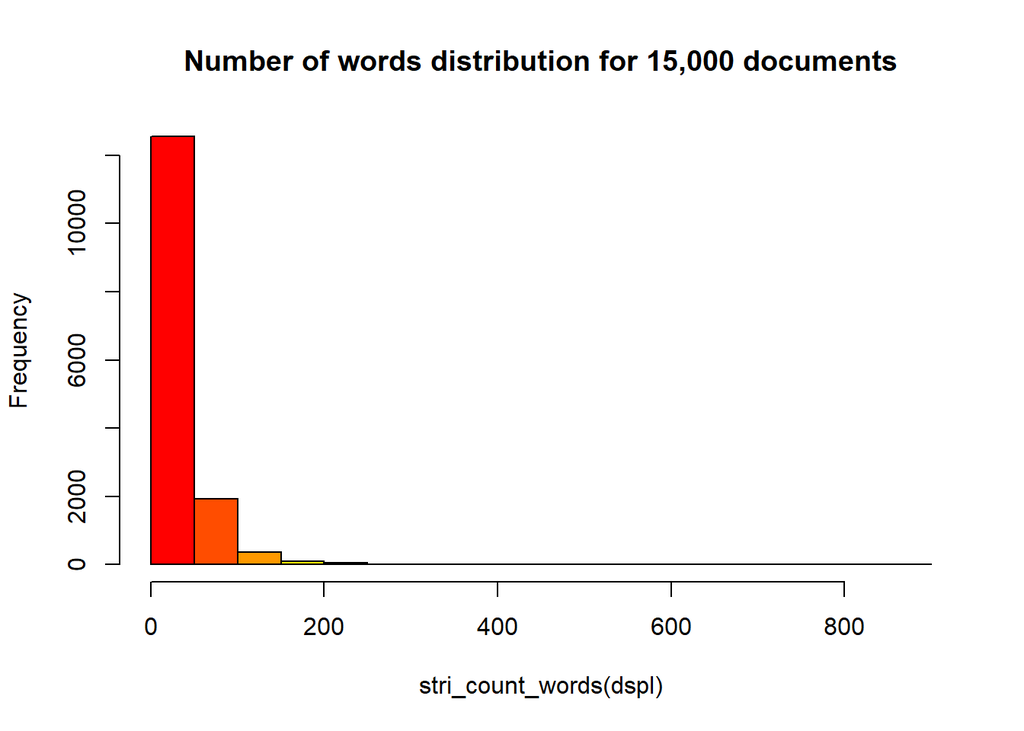

```r
hist( stri_count_words(dspl), breaks=30, col=rainbow(20), main = paste("Number of words distribution for", prettyNum(length(dspl), scientific=FALSE, big.mark=","), "documents" ))
```

```r
length(dspl)
```

```
## [1] 15000
```

## 5- Corpus and cleaning the data

The final text data needs to be cleaned to be used in the word prediction algorithm The objective is to create a cleaned Corpus file or sample of text. This Corpus will be cleaned using methods as removing whitespaces, numbers, UTR, punctuation and so on.

The library used here is TM that loads the corpus into memory and allow calls to the methods to clean the data.

```r
# text mining on sampled data
corpus <- VCorpus(VectorSource(dspl))

# switch encoding: convert character vector from UTF-8 to ASCII
corpus <- tm_map(corpus, function(x) iconv(x, 'UTF-8', 'ASCII', sub="byte"))
corpus <- tm_map(corpus, tolower, lazy = TRUE)
corpus <- tm_map(corpus,removePunctuation, preserve_intra_word_dashes=TRUE)
corpus <- tm_map(corpus, removeNumbers)
removeURL <- function(x) gsub("http[[:alnum:]]*", "", x)
corpus <- tm_map(corpus, removeURL)
corpus <- tm_map(corpus, removeWords, stopwords("english"))
corpus <- tm_map(corpus, stripWhitespace)

# assign TEXT flag
corpus <- tm_map(corpus, PlainTextDocument)

for (i in 1:10){
print(corpus[[i]]$content)
}
```

```
## [1] " seventh grade math teacher yet another victim evil mind really will see fault"
## [1] " didnt know already norwegians gather party party gin ack wine beer aquavit cognac oh yeah food lets seethere pinekjott sausage sausage mashed turnips yum first time good potatoes stuff brought dessert chocolate cake traditional southern american recipe think confused everyone chocolatyness …
## [1] " made mosaic will join mary ecthe little red houseed also little blue flowers blue monday smiling sally lovely doors monday doorways "
## [1] " iem adopted sure twin mother marilyn monroe stopped wheeling gave birth youed surprised resemblance iem sure stories true"
## [1] "angel luis juarbe new york ny"
## [1] "iem making money complicated children adventures"
## [1] " years planning years preparing successfully achieving groups goals based logic look amazing paranoid delusional insane man even now looking things logically can continue personal agenda -line bigger agenda started"
## [1] "now days warmer time clean ashes fireplace one last time love idea putting something pretty inside season sometimes use magnolia branches baskets full hydrangeas first image hello color pink pulling heart strings adore texture going rug log stool lend perfect textural balance pouff acrylic c…
## [1] "tweet include link comments another chance"
## [1] "ecbut going wilt away donet get theyell die tonight latest morning glory doesnet get live longer matter hard tryed clearly reacting now"
```

```r
## Saving the final corpus
saveRDS(corpus, file = "./finalcorpus.RData")
```

## 6- Reading final Corpus as data.frame

```r
final_corpus <- readRDS("./finalCorpus.RData")

finalCorpus <-data.frame(text=unlist(sapply(final_corpus,`[`, "content")),stringsAsFactors = FALSE)
```

## 7- Tokenization

In Natural Language Processing (NLP), n-gram is a contiguous sequence of n items from a given sequence of text or speech. Unigrams are single words. Bigrams are two words combinations. Trigrams are three-word combinations.

Let’s read the text to break it into words and sentences, and to turn it into n-grams.

The tokenizer method is allowed in R using the package RWeka.

The following function is used to extract 1-grams, 2-grams, 3-grams and 4-grams from the Corpus using RWeka.

```r
library(RWeka)
## Tokenizer function to get unigrams

unigram <- NGramTokenizer(finalCorpus, Weka_control(min = 1, max = 1,delimiters = " \\r\\n\\t.,;:\"()?!"))
unigram <- data.frame(table(unigram))
unigram <- unigram[order(unigram$Freq,decreasing = TRUE),]
names(unigram) <- c("word1", "freq")
unigram$word1 <- as.character(unigram$word1)

write.csv(unigram[unigram$freq > 1,],"unigram.csv",row.names=F)
unigram <- read.csv("unigram.csv",stringsAsFactors = F)
saveRDS(unigram, file = "unigram.RData")
head(unigram)
```

```
##   word1 freq
## 1  said 1471
## 2  will 1351
## 3   one 1294
## 4  just 1097
## 5  like 1075
## 6   can 1039
```

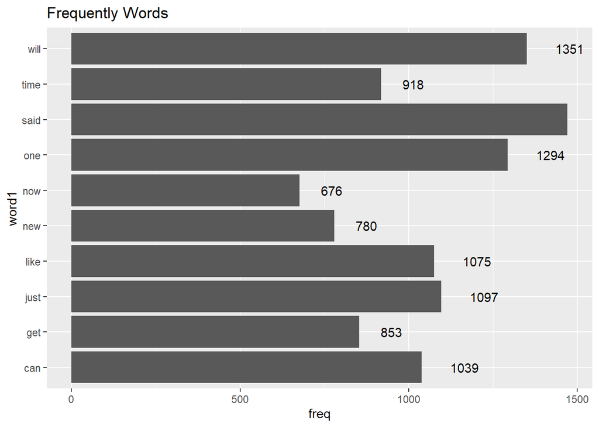

```r
## Unigram Plot
unigram <- readRDS("unigram.RData")
p1 <- ggplot(data=unigram[1:10,], aes(x = word1, y = freq))
p2 <- p1 + geom_bar(stat="identity") + coord_flip() + ggtitle("Frequently Words")
p3 <- p2 + geom_text(data = unigram[1:10,], aes(x = word1, y = freq, label = freq), hjust=-1, position = "identity")
p3
```

### 7.1 Obtaining the biGrams

```r
# Tokenizer function to get bigrams
bigram <- NGramTokenizer(finalCorpus, Weka_control(min = 2, max = 2,delimiters = " \\r\\n\\t.,;:\"()?!"))
bigram <- data.frame(table(bigram))
bigram <- bigram[order(bigram$Freq,decreasing = TRUE),]
names(bigram) <- c("words","freq")
head(bigram)
```

```
##              words freq
## 103415   last year   85
## 127319    new york   82
## 103406   last week   67
## 86580  high school   65
## 159153   right now   65
## 216417   years ago   56
```

```r
bigram$words <- as.character(bigram$words)
str2 <- strsplit(bigram$words,split=" ")
bigram <- transform(bigram,
                    one = sapply(str2,"[[",1),
                    two = sapply(str2,"[[",2))
bigram <- data.frame(word1 = bigram$one,word2 = bigram$two,freq = bigram$freq,stringsAsFactors=FALSE)

## saving files
write.csv(bigram[bigram$freq > 1,],"bigram.csv",row.names=F)
bigram <- read.csv("bigram.csv",stringsAsFactors = F)
saveRDS(bigram,"bigram.RData")
```

### 7.2 Obtaining the triGrams

```r
# Tokenizer function to get trigrams
trigram <- NGramTokenizer(finalCorpus, Weka_control(min = 3, max = 3,delimiters = " \\r\\n\\t.,;:\"()?!"))
trigram <- data.frame(table(trigram))
trigram <- trigram[order(trigram$Freq,decreasing = TRUE),]
names(trigram) <- c("words","freq")
head(trigram)
```

```
##                         words freq
## 162631 president barack obama   15
## 12298             ass ass ass    9
## 29720           cant wait see    9
## 100661         im pretty sure    8
## 141389         new york times    8
## 197719        st louis county    8
```

```r
#####################
trigram$words <- as.character(trigram$words)
str3 <- strsplit(trigram$words,split=" ")
trigram <- transform(trigram,
                     one = sapply(str3,"[[",1),
                     two = sapply(str3,"[[",2),
                     three = sapply(str3,"[[",3))
# trigram$words <- NULL
trigram <- data.frame(word1 = trigram$one,word2 = trigram$two,
                      word3 = trigram$three, freq = trigram$freq,stringsAsFactors=FALSE)
# saving files
write.csv(trigram[trigram$freq > 1,],"trigram.csv",row.names=F)
trigram <- read.csv("trigram.csv",stringsAsFactors = F)
saveRDS(trigram,"trigram.RData")
```

### 7.3 Obtaining the quadGrams

```r
# Tokenizer function to get quadgrams
quadgram <- NGramTokenizer(finalCorpus, Weka_control(min = 4, max = 4,delimiters = " \\r\\n\\t.,;:\"()?!"))
quadgram <- data.frame(table(quadgram))
quadgram <- quadgram[order(quadgram$Freq,decreasing = TRUE),]
names(quadgram) <- c("words","freq")
head(quadgram)
```

```
##                                words freq
## 12344                ass ass ass ass    8
## 113435                   la la la la    5
## 45771  cricket new zealand australia    4
## 155843        per serving calories g    4
## 179317                ruiz kick dn e    4
## 188440        serving calories g fat    4
```

```r
##################
quadgram$words <- as.character(quadgram$words)
str4 <- strsplit(quadgram$words,split=" ")
quadgram <- transform(quadgram,
                      one = sapply(str4,"[[",1),
                      two = sapply(str4,"[[",2),
                      three = sapply(str4,"[[",3),
                      four = sapply(str4,"[[",4))
# quadgram$words <- NULL
quadgram <- data.frame(word1 = quadgram$one,
                       word2 = quadgram$two,
                       word3 = quadgram$three,
                       word4 = quadgram$four,
                       freq = quadgram$freq, stringsAsFactors=FALSE)
# saving files
write.csv(quadgram[quadgram$freq > 1,],"quadgram.csv",row.names=F)
quadgram <- read.csv("quadgram.csv",stringsAsFactors = F)
saveRDS(quadgram,"quadgram.RData")
```

## 8- Next staps

### 8.1 Considerations

- All the process from reading the file, cleaning and creating the n-grams is time-consuming for your computer.
- NLP uses intensive computer resource and is necessary a lot of tests get n-grams efficient keeping minimum files sizes.

### 8.2 Next Steps

- Build a Shiny app to allow the user input the word to obtain a suggestion of the next word.
- Develop the prediction algorithm implemented in Shiny app.
- Prepare a pitch about the app and publish it at “shinyapps.io” server.